# Supplementary material, plots and tables: Study C (no random slopes, no person-mean centering)

Benjamin Simsa (benjsimsa@gmail.com)

2023-03-26

The following document is a part of the supplementary materials for my Master’s thesis “The Effect of Missing Data on the Estimation Bias, Variance, and Statistical Power in Multilevel Autoregressive(1) Models” at KU Leuven (submitted in 2023, supervisors: Prof. Eva Ceulemans, Dr. Ginette Lafit, Jordan Revol).

The main text of the thesis only reports the results obtained using person-mean centering. The present document reports and discusses the results of Simulation C (which had identical parameters to Simulation A reported in the thesis, except for NOT having used person-mean centering).

# 1 Descriptive plots and tables

# 2 Tables

## 2.1 All results

|  | miss_type | B1_sim | comp_mean | N | T.obs | B1_est | B1_pow | B1_se | B1_bias |
| --- | --- | --- | --- | --- | --- | --- | --- | --- | --- |
| 1 | block | 0.3 | 0.4 | 20 | 20 | 0.599 | 0.966 | 0.076 | 0.299 |
| 2 | block | 0.3 | 0.4 | 20 | 50 | 0.307 | 1 | 0.052 | 0.007 |
| 3 | block | 0.3 | 0.4 | 20 | 100 | 0.302 | 1 | 0.035 | 0.002 |
| 4 | block | 0.3 | 0.4 | 100 | 20 | 0.716 | 1 | 0.031 | 0.416 |
| 5 | block | 0.3 | 0.4 | 100 | 50 | 0.314 | 1 | 0.023 | 0.014 |
| 6 | block | 0.3 | 0.4 | 100 | 100 | 0.303 | 1 | 0.016 | 0.003 |
| 7 | block | 0.3 | 0.6 | 20 | 20 | 0.36 | 0.989 | 0.069 | 0.06 |
| 8 | block | 0.3 | 0.6 | 20 | 50 | 0.301 | 1 | 0.041 | 0.001 |
| 9 | block | 0.3 | 0.6 | 20 | 100 | 0.301 | 1 | 0.028 | 0.001 |
| 10 | block | 0.3 | 0.6 | 100 | 20 | 0.369 | 1 | 0.031 | 0.069 |

[output cut: 277 more lines]

### 2.1.1 Outcome: Estimation bias (MSE)

ANOVA with Estimation bias as the outcome:

ANOVA results, simulation C (no person-mean centering of the predictor). Outcome: Estimation bias

|  | Df | Sum Sq | Mean Sq | F value | p-value | Partial omega-squared |
| --- | --- | --- | --- | --- | --- | --- |
| N | 1 | 18.79 | 18.79 | 924.46 | <0.001 | 0.00 |
| T.obs | 1 | 2122.67 | 2122.67 | 104427.39 | <0.001 | 0.27 |
| miss_type | 3 | 1146.68 | 382.23 | 18804.07 | <0.001 | 0.16 |
| compliance | 1 | 610.86 | 610.86 | 30052.04 | <0.001 | 0.09 |
| B1_sim | 1 | 8.00 | 8.00 | 393.36 | <0.001 | 0.00 |
| N:T.obs | 1 | 7.14 | 7.14 | 351.43 | <0.001 | 0.00 |
| N:miss_type | 3 | 0.76 | 0.25 | 12.51 | <0.001 | 0.00 |
| T.obs:miss_type | 3 | 319.91 | 106.64 | 5246.11 | <0.001 | 0.05 |
| N:compliance | 1 | 12.73 | 12.73 | 626.34 | <0.001 | 0.00 |
| T.obs:compliance | 1 | 1264.44 | 1264.44 | 62205.42 | <0.001 | 0.18 |
| miss_type:compliance | 3 | 259.36 | 86.45 | 4253.09 | <0.001 | 0.04 |
| N:B1_sim | 1 | 0.62 | 0.62 | 30.46 | <0.001 | 0.00 |
| T.obs:B1_sim | 1 | 40.76 | 40.76 | 2005.07 | <0.001 | 0.01 |
| miss_type:B1_sim | 3 | 41.20 | 13.73 | 675.69 | <0.001 | 0.01 |
| compliance:B1_sim | 1 | 12.11 | 12.11 | 595.87 | <0.001 | 0.00 |
| Residuals | 286923 | 5832.23 | 0.02 | NA | NA | NA |

#### 2.1.1.1 Effect of the number of timepoints on estimation bias

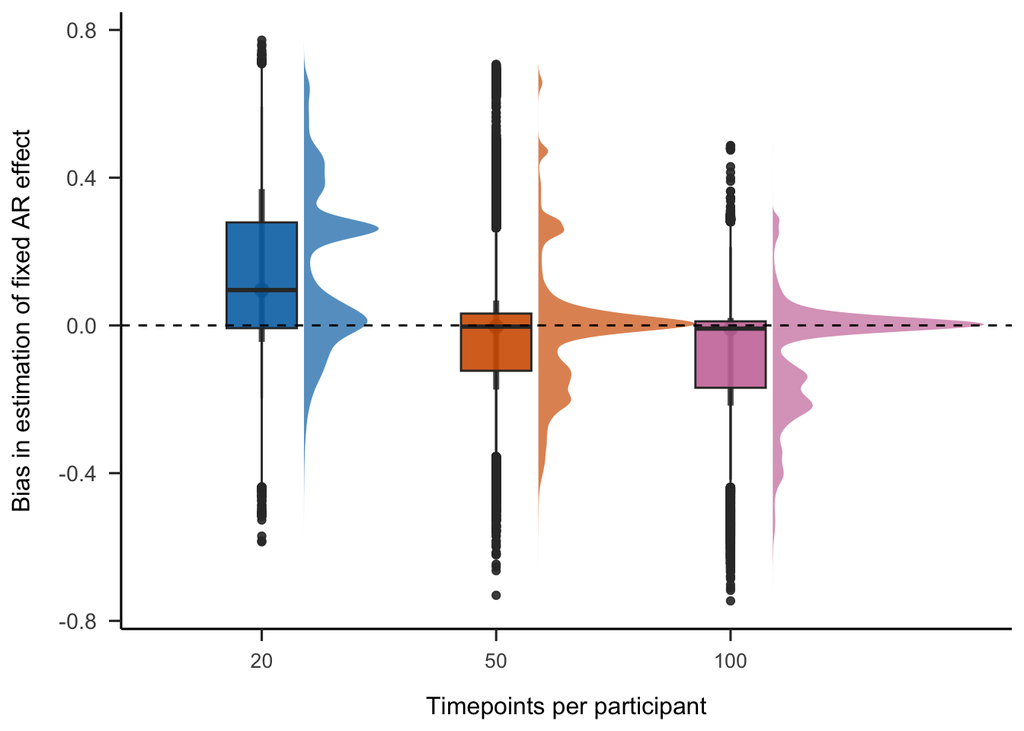

#### 2.1.1.2 Effect of missingness type on estimation bias

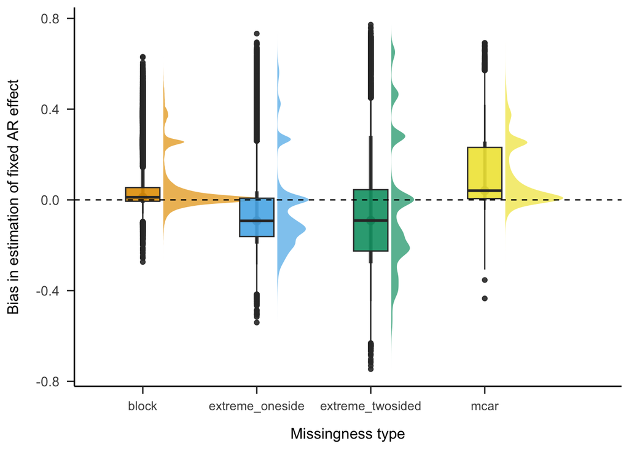

#### 2.1.1.3 Effect of the interaction between compliance and number of timepoints per participant on estimation bias

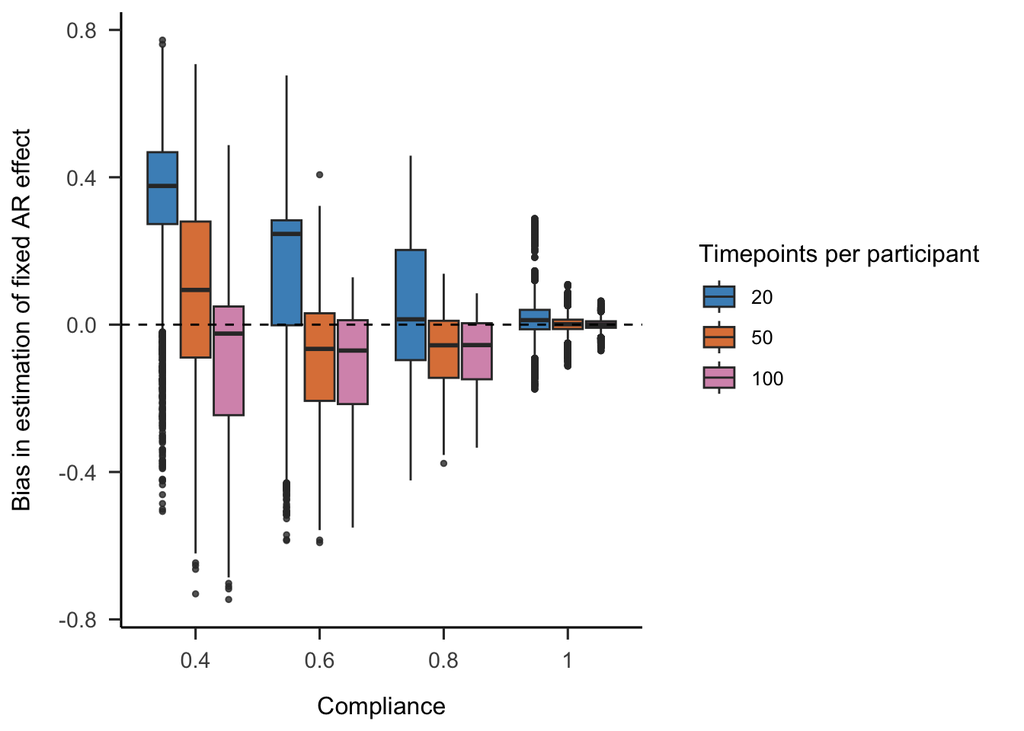

```r
(boxplot_precision_compliance_timepoints = anova_bias_df_simC %>%
  ggplot(aes(x = as.factor(compliance), y = B1_bias, fill = as.factor(T.obs))) +
  geom_boxplot(width = 0.8, alpha = 0.8, outlier.size = 1) +
  theme_apa() +
  scale_fill_manual(values = cbPalette_other) +
  ylab("Bias in estimation of fixed AR effect") +
  xlab("Compliance") +
  labs(fill='Timepoints per participant') +
  geom_hline(yintercept = 0, linetype = "dashed"))
```

In contrast to the results of Simulation A, the effect of the manipulated factors on estimation bias is much smaller. Moreover, while there is still slight underestimation when the most extreme values are missing, the magnitude of the underestimation is much smaller than in Simulation A. Additionally, when the observations are missing completely at random or in blocks, a slight overestimation of the fixed autoregressive effect occurs. The estimation becomes very precise as compliance gets higher.